# Chapter 12: Advanced forecasting methods

maurogm 2023-08-25

- Link
- Complex seasonality
  - STL with multiple seasonal periods
  - Dynamic harmonic regression with multiple seasonal periods
  - Example: Electricity demand
- Prophet
- Nerural Networks AutoRegressions (NNARs)
- Bootstrapping and Bagging

## Link

https://otexts.com/fpp3/advanced.html

## Complex seasonality

### STL with multiple seasonal periods

Veamos la serie que cuenta la cantidad de llamados que entran al call center de un banco en un período de 5 minutos.

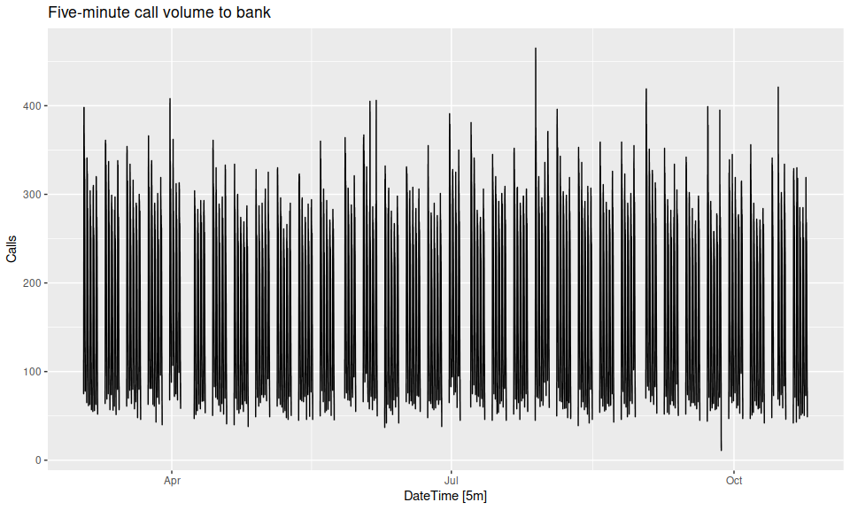

```r
bank_calls |>
  fill_gaps() |>
  autoplot(Calls) +
  labs(
    y = "Calls",
    title = "Five-minute call volume to bank"
  )
```

Tiene varias complejidades:

- Más de una estacionalidad (hora del día, semanal, anual).
- Hay franjas horarias sin datos.
- Sábados y domingos no tienen datos.

Para sortear el problema de los baches sin datos, re indexamos la serie con la función `update_tsibble`, que crea un índice regular.

```r
calls <- bank_calls |>
  mutate(t = row_number()) |>
  update_tsibble(index = t, regular = TRUE)
```

Los modelos STL tienen la capacidad de manejar múltiples estacionalidades. Podemos especificar a mano la longitud de cada período estacional (en este caso, 169 es la cantidad de períodos de 5 minutos en un día de datos). Se modela la raíz cuadrada de la serie para que los forecasts sean positivos.

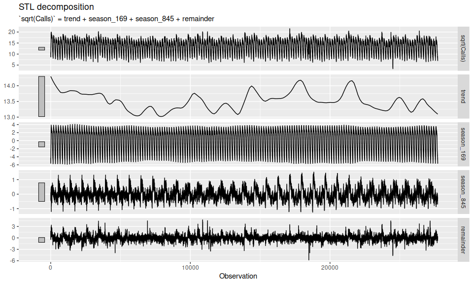

```r
calls |>
  model(
    STL(sqrt(Calls) ~ season(period = 169) +
      season(period = 5 * 169),
    robust = TRUE
    )
  ) |>
  components() |>
  autoplot() + labs(x = "Observation")
```

Gracias a STL, podemos usar STL para modelar las estacionalidades, y otro modelo para modelar la tendencia y el componente aleatorio:

```r
# Forecasts from STL+ETS decomposition
my_dcmp_spec <- decomposition_model(
  STL(sqrt(Calls) ~ season(period = 169) +
    season(period = 5 * 169),
  robust = TRUE
  ),
  ETS(season_adjust ~ season("N"))
)
fc <- calls |>
  model(my_dcmp_spec) |>
  forecast(h = 5 * 169)
```

El modelo y el forecast ya están hechos. Pero para poder graficarlos hay que volver a transformar los índices a la escala original de fechas, lo cual es medio engorroso:

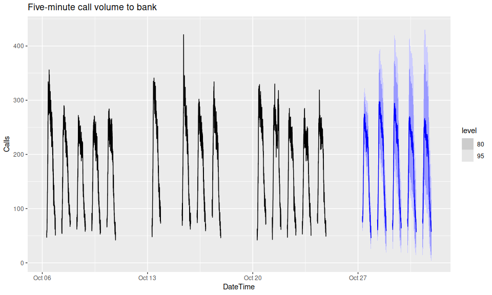

```r
# Add correct time stamps to fable
fc_with_times <- bank_calls |>
  new_data(n = 7 * 24 * 60 / 5) |>
  mutate(time = format(DateTime, format = "%H:%M:%S")) |>
  filter(
    time %in% format(bank_calls$DateTime, format = "%H:%M:%S"),
    wday(DateTime, week_start = 1) <= 5
  ) |>
  mutate(t = row_number() + max(calls$t)) |>
  left_join(fc, by = "t") |>
  # Transformo el tsibble en un fable para que se pueda plotear:
  as_fable(response = "Calls", distribution = Calls)

# Plot results with last 3 weeks of data
fc_with_times |>
  fill_gaps() |>
  autoplot(
    bank_calls |>
      tail(14 * 169) |> # 14 días de datos, para hacer legible el gráfico
      fill_gaps() # Para que llene los baches con NA, así no une con líneas
  ) +
  labs(
    y = "Calls",
    title = "Five-minute call volume to bank"
  )
```

### Dynamic harmonic regression with multiple seasonal periods

Otra opción es usar un modelo de regresión armónica dinámica, donde usamos términos de Fourier para modelar las distintas estacionalidades, y un ARIMA para el resto.

La cantidad de K pares de términos de Fourier la eligió a mano, dado que dice que usar el AICc tiende a poner K de más.

```r
fit <- calls |>
  model(
    dhr = ARIMA(sqrt(Calls) ~
      fourier(period = 169, K = 10) + # estacionalidad diaria
      fourier(period = 5 * 169, K = 5) + # estacionalidad semanal
      PDQ(0, 0, 0) + # ARIMA no debe modelar la estacionalidad
      pdq(d = 0)) # ARIMA no se debe preocupar por la estacionariedad
  )

fc <- fit |> forecast(h = 5 * 169)
```

Una vez más, hay que volver a transformar los índices a la escala original de fechas:

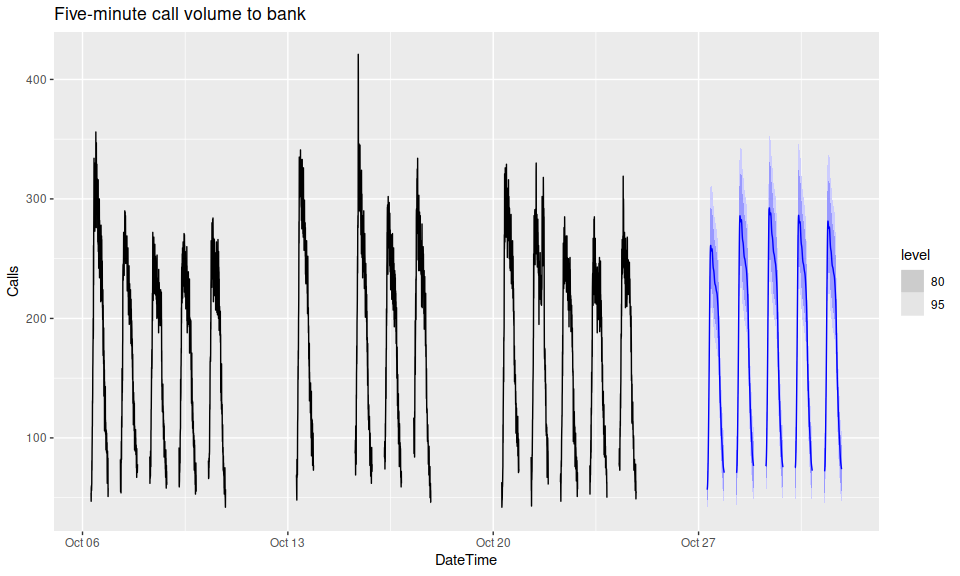

```r
# Add correct time stamps to fable
fc_with_times <- bank_calls |>
  new_data(n = 7 * 24 * 60 / 5) |>
  mutate(time = format(DateTime, format = "%H:%M:%S")) |>
  filter(
    time %in% format(bank_calls$DateTime, format = "%H:%M:%S"),
    wday(DateTime, week_start = 1) <= 5
  ) |>
  mutate(t = row_number() + max(calls$t)) |>
  left_join(fc, by = "t") |>
  as_fable(response = "Calls", distribution = Calls)

# Plot results with last 3 weeks of data
fc_with_times |>
  fill_gaps() |>
  autoplot(bank_calls |> tail(14 * 169) |> fill_gaps()) +
  labs(y = "Calls",
       title = "Five-minute call volume to bank")
```

Los intervalos de confianza son más angostos que los de STL+ETS. Habría que ver en un test set cuál de los dos modelos es mejor.

### Example: Electricity demand

Vemos un segundo ejemplo de uso de regresión armónica con múltiples estacionalidades, usando datos de demanda eléctrica. #’ Estos modelos son muy complejos, dado que además del componente estacional hay un montón de variables exógenas que pueden influir en la demanda eléctrica. Por ejemplo la temperatura:

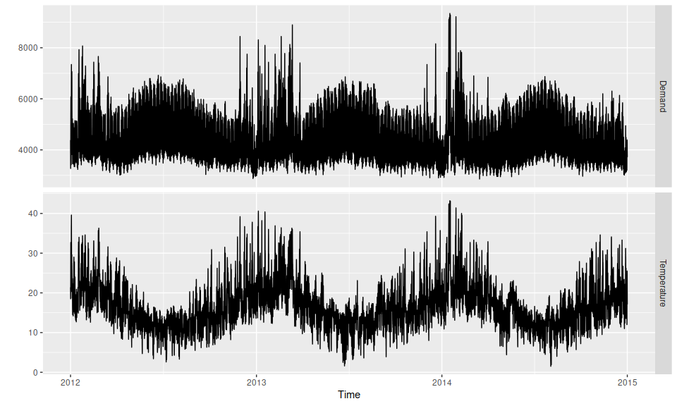

```r
vic_elec |>
  pivot_longer(Demand:Temperature, names_to = "Series") |>
  ggplot(aes(x = Time, y = value)) +
  geom_line() +
  facet_grid(rows = vars(Series), scales = "free_y") +
  labs(y = "")
```

Creamos también otros features relevantes, como día de semana, si es día laboral o no, y el máximo entre la temperatura y 18, dado que este punto pareciera ser el mínimo de demanda. Esta última variable, al ser incluida junto a la temperatura, nos permitirá modelar una función lineal a trozos.

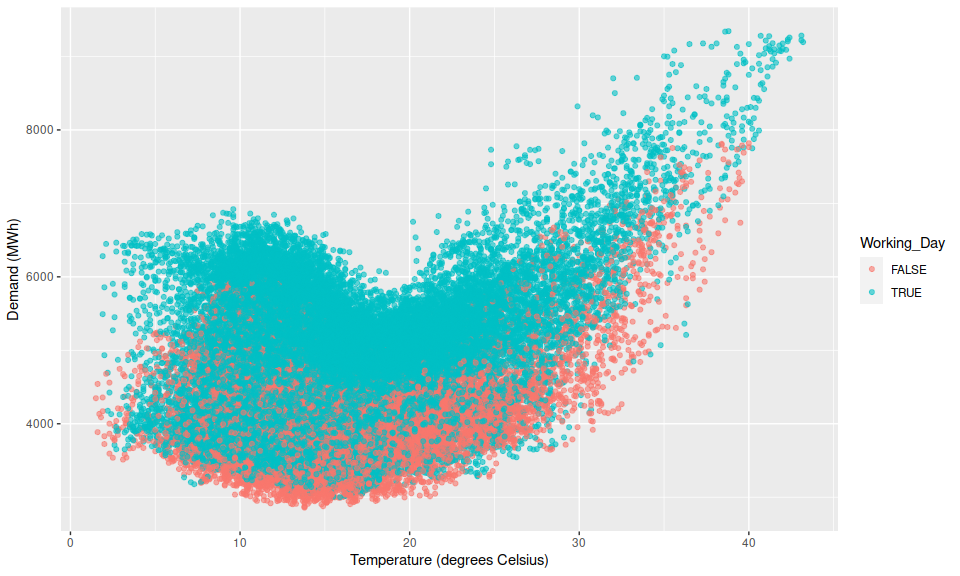

```r
elec <- vic_elec |>
  mutate(
    DOW = wday(Date, label = TRUE),
    Working_Day = !Holiday & !(DOW %in% c("Sat", "Sun")),
    Cooling = pmax(Temperature, 18)
  )
elec |>
  ggplot(aes(x=Temperature, y=Demand, col=Working_Day)) +
  geom_point(alpha = 0.6) +
  labs(x="Temperature (degrees Celsius)", y="Demand (MWh)")
```

Vemos que la demanda es más alta para temperaturas altas y bajas (¿cuadrática?), y que los días laborales tienen una demanda más alta que los fines de semana.

Metemos 3 estacionalidades: diaria, semanal y anual, además de las variables exógenas que creamos:

```r
tic()
fit <- elec |>
  model(
    ARIMA(Demand ~ PDQ(0, 0, 0) + pdq(d = 0) +
          Temperature + Cooling + Working_Day +
          fourier(period = "day", K = 10) +
          fourier(period = "week", K = 5) +
          fourier(period = "year", K = 3))
  )
toc()
```

```
## 323.406 sec elapsed
```

Modelo resultante:

```r
fit
```

```
## # A mable: 1 x 1
##   `ARIMA(Demand ~ PDQ(0, 0, 0) + pdq(d = 0) + Temperature + Cooling + \n    Wo…`
##                                                                          <model>
## 1                                                    <LM w/ ARIMA(1,0,5) errors>
```

Para poder forecastear, tenemos que crear un nuevo dataset con los valores de las variables exógenas para los períodos que queremos forecastear. Asumamos que las próximas 48 horas van a tener la misma temperatura que las últimas 48 horas, y aclaremos que el día 1 de enero no es laboral:

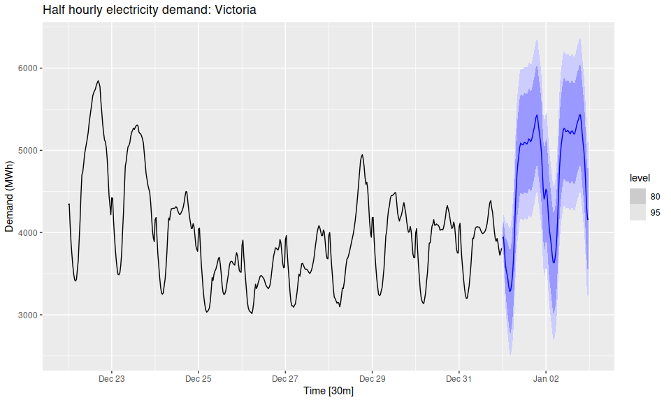

```r
elec_newdata <- new_data(elec, 2*48) |>
  mutate(
    Temperature = tail(elec$Temperature, 2 * 48),
    Date = lubridate::as_date(Time),
    DOW = wday(Date, label = TRUE),
    Working_Day = (Date != "2015-01-01") &
                   !(DOW %in% c("Sat", "Sun")),
    Cooling = pmax(Temperature, 18)
  )
fc <- fit |>
  forecast(new_data = elec_newdata)
fc |>
  autoplot(elec |> tail(10 * 48)) +
  labs(title="Half hourly electricity demand: Victoria",
       y = "Demand (MWh)", x = "Time [30m]")
```

A pesar de todo, resulta que el modelo dista de ser perfecto, como se ve en la autocorrelación de los residuos:

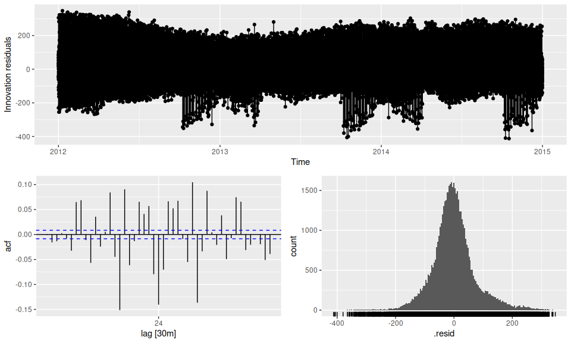

```r
fit |> gg_tsresiduals()
```

## Prophet

Ver el capítulo. [Link](https://otexts.com/fpp3/prophet.html)

## Vector autoregressions (VARs)

Modelamos el Ingreso y el Consumo juntos, ambos en función de los lags de sí mismos y del otro. Por defecto se usa el AICc para elegir los hiperparámetros del modelo, aunque a veces es mejor usar el BIC. Ello se puede especificar con el argumento `ic`.

```r
fit <- us_change |>
  model(
    aicc = VAR(vars(Consumption, Income)),
    bic = VAR(vars(Consumption, Income), ic = "bic")
  )
fit
```

```
## # A mable: 1 x 2
##               aicc              bic
##            <model>          <model>
## 1 <VAR(5) w/ mean> <VAR(1) w/ mean>
```

```r
glance(fit)
```

```
## # A tibble: 2 × 6
##   .model sigma2        log_lik   AIC  AICc   BIC
##   <chr>  <list>          <dbl> <dbl> <dbl> <dbl>
## 1 aicc   <dbl [2 × 2]>   -373.  798.  806.  883.
## 2 bic    <dbl [2 × 2]>   -408.  836.  837.  869.
```

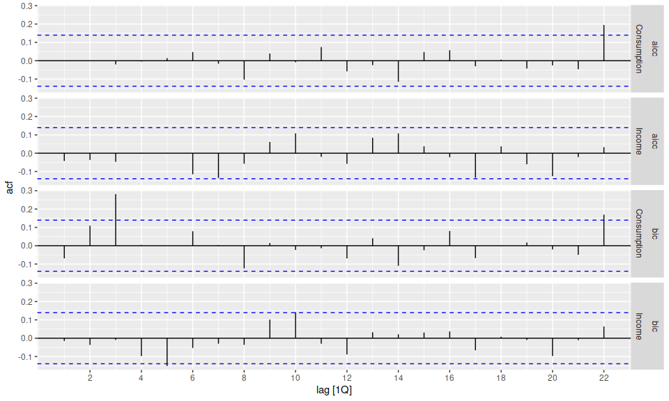

```r
fit |>
  augment() |>
  ACF(.innov) |>
  autoplot()
```

## Nerural Networks AutoRegressions (NNARs)

Usamos la función `NNETAR` para modelar la cantidad anual de manchas solares con una red neuronal auto regresiva.

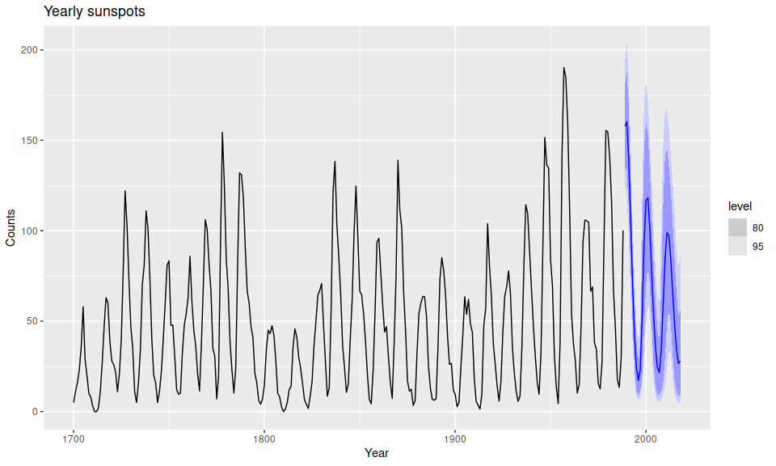

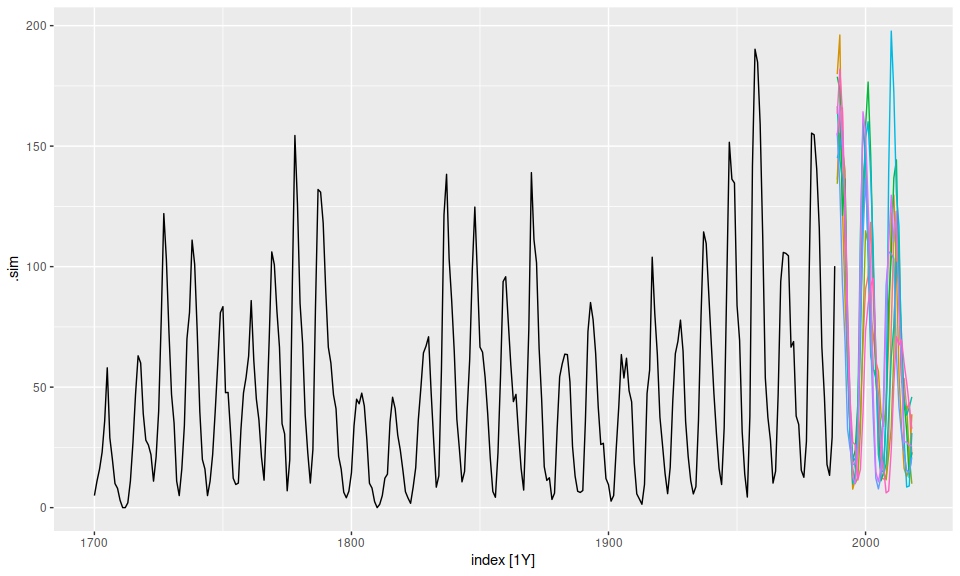

```r
sunspots <- sunspot.year |> as_tsibble()
fit <- sunspots |>
  model(NNETAR(sqrt(value)))

fit |>
  forecast(h = 30) |>
  autoplot(sunspots) +
  labs(x = "Year", y = "Counts", title = "Yearly sunspots")


fit |>
  generate(times = 9, h = 30) |>
  autoplot(.sim) +
  autolayer(sunspots, value) +
  theme(legend.position = "none")
```

## Bootstrapping and Bagging

Primero descomponemos la serie original en tendencia, estacionalidad y reminder:

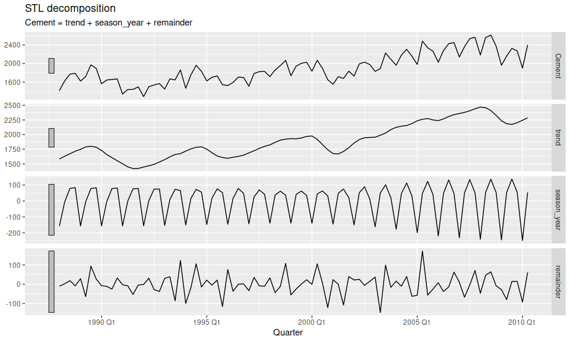

```r
cement <- aus_production |>
  filter(year(Quarter) >= 1988) |>
  select(Quarter, Cement)
cement_stl <- cement |>
  model(stl = STL(Cement))
cement_stl |>
  components() |>
  autoplot()
```

La función `generate` está preparada para tomar un modelo STL y generar series bootstrapeadas. Es importante usar un `bootstrap_block_size` razonable, para que al resamplear el reminder se utilicen bloques de datos consecutivos, y así poder mantener las relaciones de la serie original que no hayan sido captadas por STL.

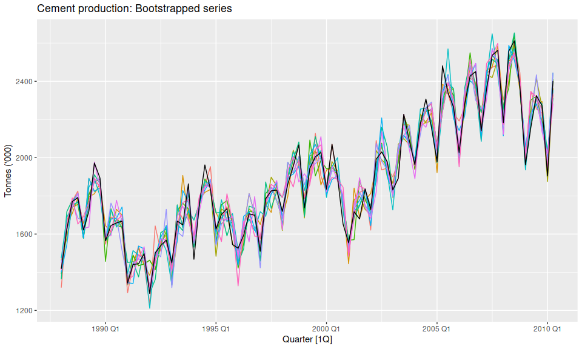

```r
cement_stl |>
  generate(new_data = cement, times = 10,
           bootstrap_block_size = 8) |>
  autoplot(.sim) +
  autolayer(cement, Cement) +
  guides(colour = "none") +
  labs(title = "Cement production: Bootstrapped series",
       y="Tonnes ('000)")
```

Para poder hacer bagging, tenemos que resamplear muchísimas series, para luego entrenar un modelo distinto en cada una de ellas. Es un proceso que puede llevar un buen tiempo:

```r
sim <- cement_stl |>
  generate(new_data = cement, times = 100,
           bootstrap_block_size = 8) |>
  select(-.model, -Cement)

tic()
ets_forecasts <- sim |>
  model(ets = ETS(.sim)) |>
  forecast(h = 12)
toc()
```

```
## 18.762 sec elapsed
```

Esto me da luego una multitud de forecasts, uno por cada serie bootstrapeada.

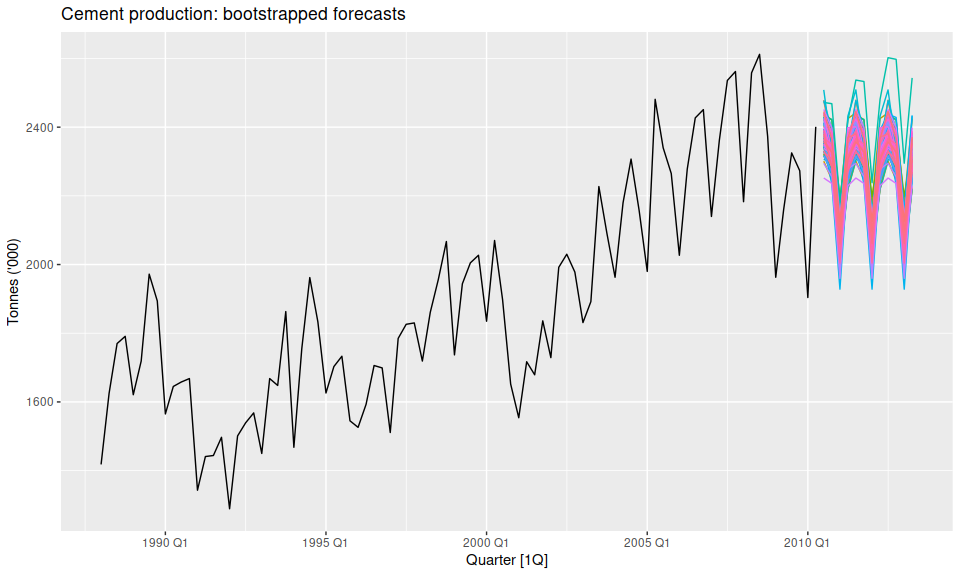

```r
ets_forecasts |>
  update_tsibble(key = .rep) |>
  autoplot(.mean) +
  autolayer(cement, Cement) +
  guides(colour = "none") +
  labs(title = "Cement production: bootstrapped forecasts",
       y="Tonnes ('000)")
```

Cómo consolide esta información dependerá de cuál sea mi objetivo.

- ¿Uso las medias de los forecasts, o también la incertidumbre de cada modelo? No me queda claro si al hacer eso estaría contando dos veces la incertidumbre, o haciendo lo correcto.
- ¿No debería dejar al menos la parte final de la serie sin bootstrapear, considerando que los forecasts de muchos modelos se construirán continuando desde esos puntos?